# Expectation Maximation

Diptanshu Singh

Oct 5, 2018

## Expectation Maximization Algorithm

In statistics, an expectation–maximization (EM) algorithm is an iterative method to find maximum likelihood or maximum a posteriori (MAP) estimates of parameters in statistical models, where the model depends on unobserved latent variables. The EM iteration alternates between performing an expectation (E) step, which creates a function for the expectation of the log-likelihood evaluated using the current estimate for the parameters, and a maximization (M) step, which computes parameters maximizing the expected log-likelihood found on the E step. These parameter-estimates are then used to determine the distribution of the latent variables in the next E step.

### Calculating parameters of a gaussian distrbution through Expectation/Maximization

Let
$${\displaystyle \mathbf {x} =(\mathbf {x} _{1},\mathbf {x} _{2},\ldots ,\mathbf {x} _{n})} \mathbf{x} = (\mathbf{x}_1,\mathbf{x}_2,\ldots,\mathbf{x}_n)$$
be a sample of n independent observations from a mixture of two multivariate normal distributions of dimension d, and let
$${\displaystyle \mathbf {z} =(z_{1},z_{2},\ldots ,z_{n})} \mathbf{z} = (z_1,z_2,\ldots,z_n)$$
be the latent variables that determine the component from which the observation originates.

$${\displaystyle X_{i}|(Z_{i}=1)\sim {\mathcal {N}}_{d}({\boldsymbol {\mu }}_{1},\Sigma _{1})} X_i |(Z_i = 1) \sim \mathcal{N}_d(\boldsymbol{\mu}_1,\Sigma_1)$$
and
$${\displaystyle X_{i}|(Z_{i}=2)\sim {\mathcal {N}}_{d}({\boldsymbol {\mu }}_{2},\Sigma _{2})} X_i |(Z_i = 2) \sim \mathcal{N}_d(\boldsymbol{\mu}_2,\Sigma_2)$$
where

$${\displaystyle \operatorname {P} (Z_{i}=1)=\tau _{1}\,} \operatorname{P} (Z_i = 1 ) = \tau_1 \,$$
and
$${\displaystyle \operatorname {P} (Z_{i}=2)=\tau _{2}=1-\tau _{1}} \operatorname{P} (Z_i=2) = \tau_2 = 1-\tau_1$$
The aim is to estimate the unknown parameters representing the mixing value between the Gaussians and the means and covariances of each:

$${\displaystyle \theta ={\big (}{\boldsymbol {\tau }},{\boldsymbol {\mu }}_{1},{\boldsymbol {\mu }}_{2},\Sigma _{1},\Sigma _{2}{\big )}}$$
where the likelihood function is

$${\displaystyle L(\theta ;\mathbf {x} )=\prod _{i=1}^{n}\sum _{j=1}^{2}\tau _{j}\ f(\mathbf {x} _{i};{\boldsymbol {\mu }}_{j},\Sigma _{j})} L(\theta ;{\mathbf {x}})$$

First we will define some helper functions.

```r
# We use log transform as the likelihood values can be very small and can lead to numerical Underflow.

log1pe <- local({
  LOG.EPS2 <- log(.Machine$double.eps / 2)
  function (x) {
    l <- 0
    if (x > 0) { l <- x; x <- -x } # range reduction
    if (x < LOG.EPS2) l else l + log(1 + exp(x))
  }
})

#Calculating the log density of normal distribution
# x ~ N(mu, S), C = chol(S), compute log density of x
ldmvnorm <- function (x, mu, C) {
  v <- backsolve(C, x - mu, transpose = TRUE)
  -sum(log(diag(C))) - 0.5 * sum(v * v)
}
```

```r
#Auxillary function for E-step to calculate the joint log likelihood (log (pi_t))
log.pi <- function (xi, em, C1, C2) {
  f1 <- ldmvnorm(xi, em$mu1, C1)
  f2 <- ldmvnorm(xi, em$mu2, C2)
  ll <- log(em$lambda / (1 - em$lambda)) # logit(lambda)
  -log1pe(-ll + f2 - f1)
}

# `x` has observations in columns
# `em` stores parameters: list(mu1, mu2, sigma1, sigma2, lambda)
em.update <- function (x, em) {
  # [ E-step ]
  p <- exp(apply(x, 2, log.pi, em, chol(em$sigma1), chol(em$sigma2)))
  # [ M-step ]
  lambda <- mean(p)
  mu1 <- apply(x, 1, weighted.mean, p)
  mu2 <- apply(x, 1, weighted.mean, 1 - p)
  sigma1 <- cov.wt(t(x), wt = p, center = mu1, method = "ML")$cov
  sigma2 <- cov.wt(t(x), wt = 1 - p, center = mu2, method = "ML")$cov
  list(lambda = lambda, mu1 = mu1, mu2 = mu2,
       sigma1 = sigma1, sigma2 = sigma2, p = p)
}
```

Plotting a bivarate gaussian with EM estimates

```r
# plot (x - mu)' * sigma^(-1) * (x - mu) = qchisq(alpha, 2)
ellipse <- function (mu, sigma, alpha, ns=100) {
  p <- matrix(nrow = 2, ncol = ns) # points
  t <- seq(0, 2 * pi, length.out = ns) # param (angle)
  e <- eigen(sigma)
  s <- sqrt(e$values * qchisq(alpha, 2))
  # scale
  p[1,] <- s[1] * cos(t)
  p[2,] <- s[2] * sin(t)
  return(e$vectors %*% p + mu)
}


ALPHA.LEVELS <- c(.25, .5, .75, .95)
plot.em <- function (x, em, ep = NULL) {
  if (!is.null(ep)) {
    ind <- which(ep >= .5)
    plot(x[1,], x[2,], type = "n",
        xlab = expression(X[1]), ylab = expression(X[2]))
    points(x[1, ind], x[2, ind], pch = 19,
           col = rgb(0, 0, 1, alpha = ep[ind] / .5 - 1))
    points(x[1, -ind], x[2, -ind], pch = 19,
           col = rgb(1, 0, 0, alpha = 1 - ep[-ind] / .5))
  }
  else
    plot(x[1,], x[2,], pch = 19, col = "gray",
        xlab = expression(X[1]), ylab = expression(X[2]))
  points(em$mu1[1], em$mu1[2], pch = 4, col="blue")
  points(em$mu2[1], em$mu2[2], pch = 4, col="red")
  for (alpha in ALPHA.LEVELS) {
    p <- ellipse(em$mu1, em$sigma1, alpha)
    lines(p[1,], p[2,], col = "blue")
    p <- ellipse(em$mu2, em$sigma2, alpha)
    lines(p[1,], p[2,], col = "red")
  }
}
```

We will use the algoithm to determine the parameters for a bivariate Gaussian. We will start by putting random estimate for the two distributions.

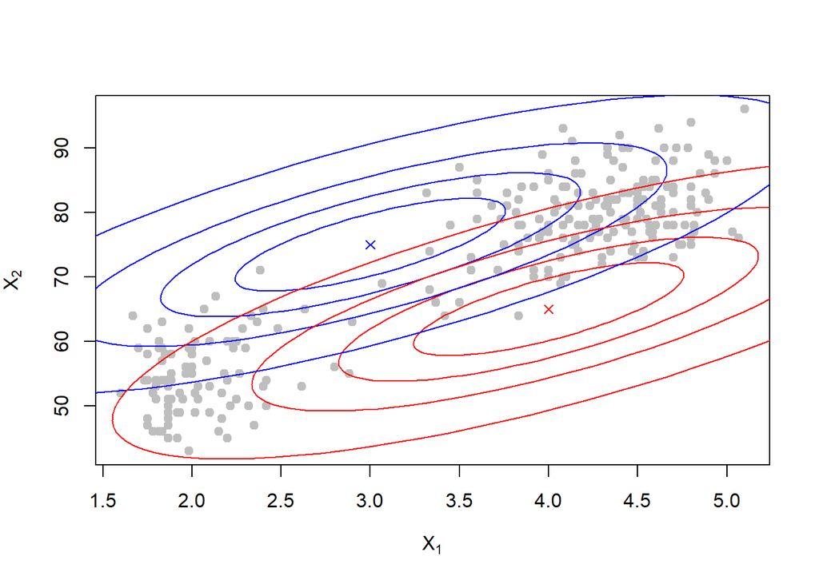

```r
data(faithful) # Old Faithful dataset
x <- t(as.matrix(faithful))
em <- list(mu1 = c(3, 75), mu2 = c(4, 65),
           sigma1 = matrix(c(1, 7, 7, 90), nrow = 2),
           sigma2 = matrix(c(1, 7, 7, 90), nrow = 2),
           lambda = .5)

plot.em(x,em)
```

Next we perform one EM update and see the result

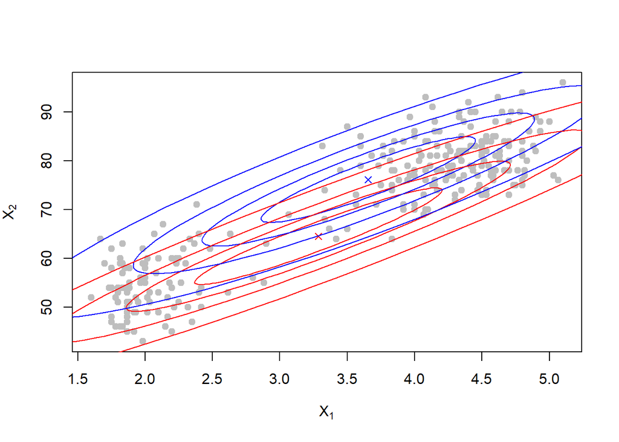

```r
em <- em.update(x,em)
plot.em(x,em)
```

EM estimates after 10 updates

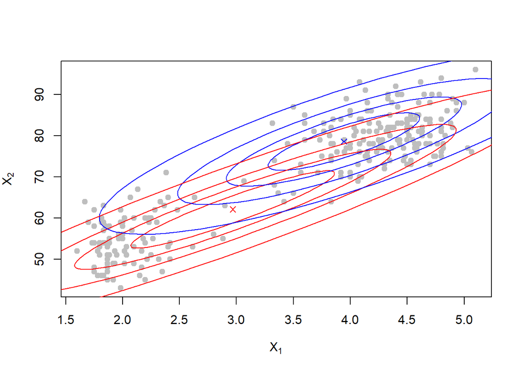

```r
for (i in 1:10){
  em <- em.update(x,em)
}

plot.em(x,em)
```

EM estimates after 100 updates

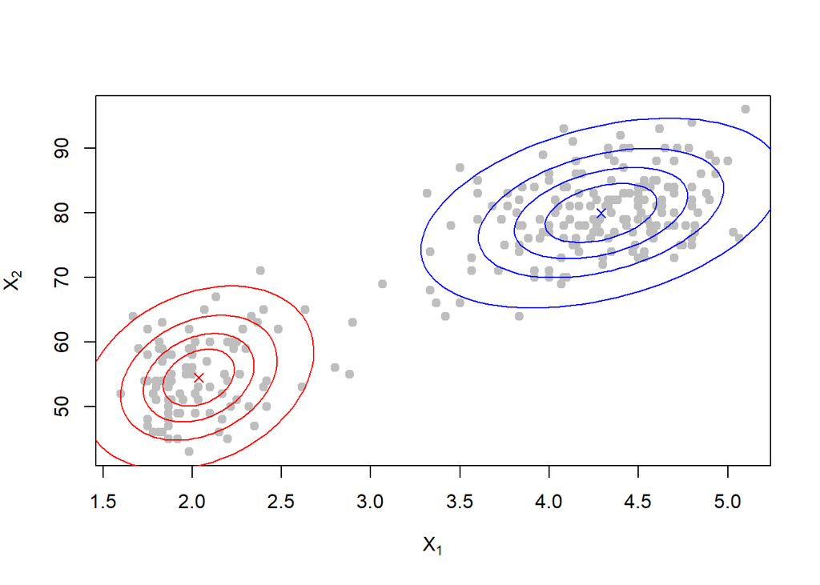

```r
for (i in 10:100){
  em <- em.update(x,em)
}

plot.em(x,em)
```

EM typically converges to a local optimum, not necessarily the global optimum, with no bound on the convergence rate in general. It is possible that it can be arbitrarily poor in high dimensions and there can be an exponential number of local optima. Hence, a need exists for alternative methods for guaranteed learning, especially in the high-dimensional setting.

Another flaw with the EM algorithm is that we need to know the structure of data beforehand, such as we have only 2 gaussian distribution in this case.